# groupProject

Vince

2024-03-07

##Loading libraries

```r
library(readr)
library(dplyr)
library(tidyverse)
```

```r
library(stringr)
library(ggplot2)
```

## Combining Datasets

### Read CSV Files

```r
forest_km <- read_delim("forest_area_km.csv")
forest_percent <- read_delim("forest_area_percent.csv")
global_temp <- read_delim("Global_Temperatures.csv")
```

### Checking first few columns in each csv

```r
head(forest_km,5)
```

```
## # A tibble: 5 × 34
##   `Country Name` `Country Code` `1990` `1991` `1992` `1993` `1994` `1995` `1996`
##   <chr>          <chr>           <dbl>  <dbl>  <dbl>  <dbl>  <dbl>  <dbl>  <dbl>
## 1 Afghanistan    AFG            12084. 12084. 12084. 12084. 12084. 12084. 12084.
## 2 Albania        ALB             7888   7868.  7849   7830.  7810   7790.  7771
## 3 Algeria        DZA            16670  16582  16494  16406  16318  16230  16142
## 4 American Samoa ASM              181.   180.   180.   180.   179.   179    179.
## 5 Andorra        AND              160    160    160    160    160    160    160
## # ℹ 25 more variables: `1997` <dbl>, `1998` <dbl>, `1999` <dbl>, `2000` <dbl>,
## #   `2001` <dbl>, `2002` <dbl>, `2003` <dbl>, `2004` <dbl>, `2005` <dbl>,
## #   `2006` <dbl>, `2007` <dbl>, `2008` <dbl>, `2009` <dbl>, `2010` <dbl>,
## #   `2011` <dbl>, `2012` <dbl>, `2013` <dbl>, `2014` <dbl>, `2015` <dbl>,
## #   `2016` <dbl>, `2017` <dbl>, `2018` <dbl>, `2019` <dbl>, `2020` <dbl>,
## #   `2021` <dbl>
```

```r
head(forest_percent,5)
```

```
## # A tibble: 5 × 34
##   `Country Name` `Country Code` `1990` `1991` `1992` `1993` `1994` `1995` `1996`
##   <chr>          <chr>           <dbl>  <dbl>  <dbl>  <dbl>  <dbl>  <dbl>  <dbl>
## 1 Afghanistan    AFG             1.85   1.85   1.85   1.85   1.85   1.85   1.85
## 2 Albania        ALB            28.8   28.7   28.6   28.6   28.5   28.4   28.4
## 3 Algeria        DZA             0.700  0.696  0.693  0.689  0.685  0.681  0.678
## 4 American Samoa ASM            90.4   90.2   90.0   89.8   89.7   89.5   89.3
## 5 Andorra        AND            34.0   34.0   34.0   34.0   34.0   34.0   34.0
## # ℹ 25 more variables: `1997` <dbl>, `1998` <dbl>, `1999` <dbl>, `2000` <dbl>,
## #   `2001` <dbl>, `2002` <dbl>, `2003` <dbl>, `2004` <dbl>, `2005` <dbl>,
## #   `2006` <dbl>, `2007` <dbl>, `2008` <dbl>, `2009` <dbl>, `2010` <dbl>,
## #   `2011` <dbl>, `2012` <dbl>, `2013` <dbl>, `2014` <dbl>, `2015` <dbl>,
## #   `2016` <dbl>, `2017` <dbl>, `2018` <dbl>, `2019` <dbl>, `2020` <dbl>,
## #   `2021` <dbl>
```

```r
head(global_temp,5)
```

```
## # A tibble: 5 × 5
##   region country city     year average_temperature
##   <chr>  <chr>   <chr>   <dbl>               <dbl>
## 1 Africa Algeria Algiers  1997                64.9
## 2 Africa Algeria Algiers  1998                63.6
## 3 Africa Algeria Algiers  1999                64.9
## 4 Africa Algeria Algiers  2000                64.2
## 5 Africa Algeria Algiers  2001                64.7
```

### Cleaning Up CSV Files

#### Convert “Country Name” header to “country”

```r
forest_km <- forest_km %>%
  rename(country = `Country Name`)
  head(forest_km, 5)
```

```
## # A tibble: 5 × 34
##   country `Country Code` `1990` `1991` `1992` `1993` `1994` `1995` `1996` `1997`
##   <chr>   <chr>           <dbl>  <dbl>  <dbl>  <dbl>  <dbl>  <dbl>  <dbl>  <dbl>
## 1 Afghan… AFG            12084. 12084. 12084. 12084. 12084. 12084. 12084. 12084.
## 2 Albania ALB             7888   7868.  7849   7830.  7810   7790.  7771   7752.
## 3 Algeria DZA            16670  16582  16494  16406  16318  16230  16142  16054
## 4 Americ… ASM              181.   180.   180.   180.   179.   179    179.   178.
## 5 Andorra AND              160    160    160    160    160    160    160    160
## # ℹ 24 more variables: `1998` <dbl>, `1999` <dbl>, `2000` <dbl>, `2001` <dbl>,
## #   `2002` <dbl>, `2003` <dbl>, `2004` <dbl>, `2005` <dbl>, `2006` <dbl>,
## #   `2007` <dbl>, `2008` <dbl>, `2009` <dbl>, `2010` <dbl>, `2011` <dbl>,
## #   `2012` <dbl>, `2013` <dbl>, `2014` <dbl>, `2015` <dbl>, `2016` <dbl>,
## #   `2017` <dbl>, `2018` <dbl>, `2019` <dbl>, `2020` <dbl>, `2021` <dbl>
```

#### Convert “Country Name” header to “country”

```r
forest_percent <- forest_percent %>%
  rename(country = `Country Name`)
  head(forest_km, 5)
```

```
## # A tibble: 5 × 34
##   country `Country Code` `1990` `1991` `1992` `1993` `1994` `1995` `1996` `1997`
##   <chr>   <chr>           <dbl>  <dbl>  <dbl>  <dbl>  <dbl>  <dbl>  <dbl>  <dbl>
## 1 Afghan… AFG            12084. 12084. 12084. 12084. 12084. 12084. 12084. 12084.
## 2 Albania ALB             7888   7868.  7849   7830.  7810   7790.  7771   7752.
## 3 Algeria DZA            16670  16582  16494  16406  16318  16230  16142  16054
## 4 Americ… ASM              181.   180.   180.   180.   179.   179    179.   178.
## 5 Andorra AND              160    160    160    160    160    160    160    160
## # ℹ 24 more variables: `1998` <dbl>, `1999` <dbl>, `2000` <dbl>, `2001` <dbl>,
## #   `2002` <dbl>, `2003` <dbl>, `2004` <dbl>, `2005` <dbl>, `2006` <dbl>,
## #   `2007` <dbl>, `2008` <dbl>, `2009` <dbl>, `2010` <dbl>, `2011` <dbl>,
## #   `2012` <dbl>, `2013` <dbl>, `2014` <dbl>, `2015` <dbl>, `2016` <dbl>,
## #   `2017` <dbl>, `2018` <dbl>, `2019` <dbl>, `2020` <dbl>, `2021` <dbl>
```

#### Convert “year” data type from double to char

```r
global_temp <- global_temp %>%
  mutate(year = as.character(year))
```

### Convert Forms from wide to long form

```r
countryList <- c('country', 'Country Code')

longForestKM <- forest_km %>%
   pivot_longer(!countryList, names_to = "year", values_to = "km")
longForestKM
```

```
## # A tibble: 8,288 × 4
##    country     `Country Code` year      km
##    <chr>       <chr>          <chr>  <dbl>
##  1 Afghanistan AFG            1990  12084.
##  2 Afghanistan AFG            1991  12084.
##  3 Afghanistan AFG            1992  12084.
##  4 Afghanistan AFG            1993  12084.
##  5 Afghanistan AFG            1994  12084.
##  6 Afghanistan AFG            1995  12084.
##  7 Afghanistan AFG            1996  12084.
##  8 Afghanistan AFG            1997  12084.
##  9 Afghanistan AFG            1998  12084.
## 10 Afghanistan AFG            1999  12084.
## # ℹ 8,278 more rows
```

```r
longForestPercent <- forest_percent %>%
   pivot_longer(!countryList, names_to = "year", values_to = "percent")
longForestPercent
```

```
## # A tibble: 8,256 × 4
##    country     `Country Code` year  percent
##    <chr>       <chr>          <chr>   <dbl>
##  1 Afghanistan AFG            1990     1.85
##  2 Afghanistan AFG            1991     1.85
##  3 Afghanistan AFG            1992     1.85
##  4 Afghanistan AFG            1993     1.85
##  5 Afghanistan AFG            1994     1.85
##  6 Afghanistan AFG            1995     1.85
##  7 Afghanistan AFG            1996     1.85
##  8 Afghanistan AFG            1997     1.85
##  9 Afghanistan AFG            1998     1.85
## 10 Afghanistan AFG            1999     1.85
## # ℹ 8,246 more rows
```

### Joining Table Together for Forest

```r
forest_km_percent <- left_join(longForestKM, longForestPercent)
forest_km_percent
```

```
## # A tibble: 8,288 × 5
##    country     `Country Code` year      km percent
##    <chr>       <chr>          <chr>  <dbl>   <dbl>
##  1 Afghanistan AFG            1990  12084.    1.85
##  2 Afghanistan AFG            1991  12084.    1.85
##  3 Afghanistan AFG            1992  12084.    1.85
##  4 Afghanistan AFG            1993  12084.    1.85
##  5 Afghanistan AFG            1994  12084.    1.85
##  6 Afghanistan AFG            1995  12084.    1.85
##  7 Afghanistan AFG            1996  12084.    1.85
##  8 Afghanistan AFG            1997  12084.    1.85
##  9 Afghanistan AFG            1998  12084.    1.85
## 10 Afghanistan AFG            1999  12084.    1.85
## # ℹ 8,278 more rows
```

### Inner Joining global temp together to create a final set

```r
final_set2 <- inner_join(global_temp, forest_km_percent)
final_set2
```

```
## # A tibble: 2,409 × 8
##    region country city    year  average_temperature `Country Code`    km percent
##    <chr>  <chr>   <chr>   <chr>               <dbl> <chr>          <dbl>   <dbl>
##  1 Africa Algeria Algiers 1997                 64.9 DZA            16054   0.674
##  2 Africa Algeria Algiers 1998                 63.6 DZA            15966   0.670
##  3 Africa Algeria Algiers 1999                 64.9 DZA            15878   0.667
##  4 Africa Algeria Algiers 2000                 64.2 DZA            15790   0.663
##  5 Africa Algeria Algiers 2001                 64.7 DZA            16129   0.677
##  6 Africa Algeria Algiers 2002                 64.1 DZA            16468   0.691
##  7 Africa Algeria Algiers 2003                 65.5 DZA            16807   0.706
##  8 Africa Algeria Algiers 2004                 64.1 DZA            17146   0.720
##  9 Africa Algeria Algiers 2005                 62.9 DZA            17485   0.734
## 10 Africa Algeria Algiers 2006                 64.9 DZA            17824   0.748
## # ℹ 2,399 more rows
```

```r
final_set2 <- final_set2 %>%
  mutate(year = as.numeric(year))
```

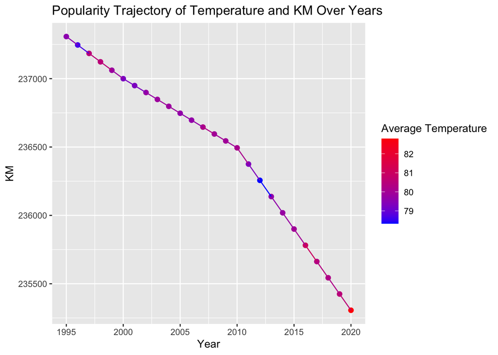

```r
final_set2 %>%
  filter(country == "Gabon") %>%
  ggplot(aes(x = year, y = km, color = average_temperature)) +
  geom_point(size = 2) +
  geom_line() +
  scale_color_gradient(low = "blue", high = "red") +
  labs(x = "Year", y = "KM", color = "Average Temperature",
       title = "Popularity Trajectory of Temperature and KM Over Years")
```

```r
library(scales)
```

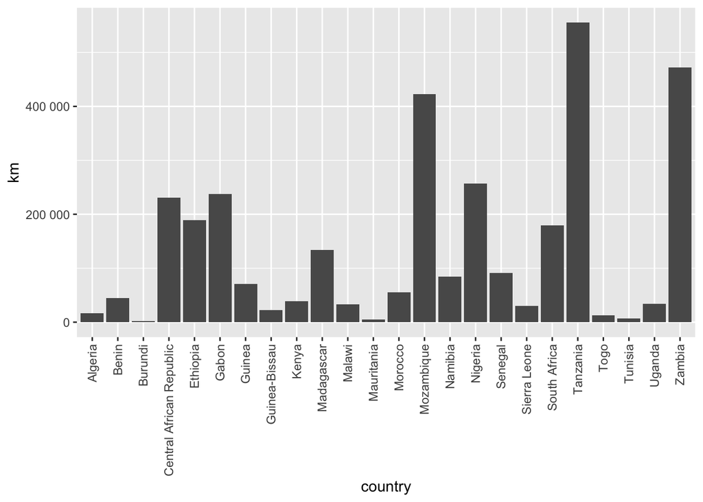

```r
final_set2 %>%
  filter(region == "Africa", year == "1995") %>%
  ggplot() +
  geom_bar(mapping = aes(x = country, y = km), stat = "identity") +
  theme(axis.text.x = element_text(angle = 90, vjust = 0.5, hjust=1)) +
  scale_y_continuous(labels = label_number())
```

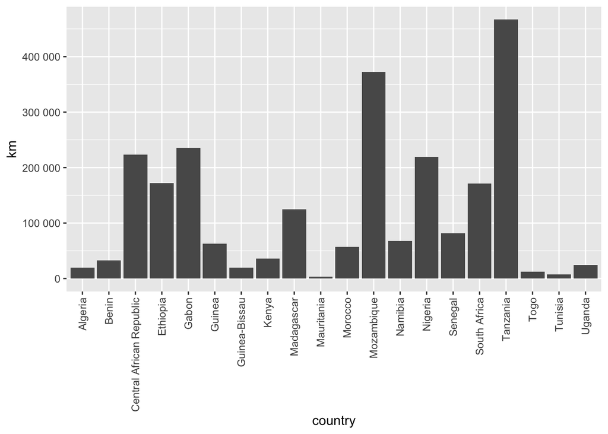

```r
final_set2 %>%
  filter(region == "Africa", year == "2018") %>%
  ggplot() +
  geom_bar(mapping = aes(x = country, y = km), stat = "identity") +
  theme(axis.text.x = element_text(angle = 90, vjust = 0.5, hjust=1)) +
  scale_y_continuous(labels = label_number())
```

# At which average temperature do the forests in that area tend to thrive?

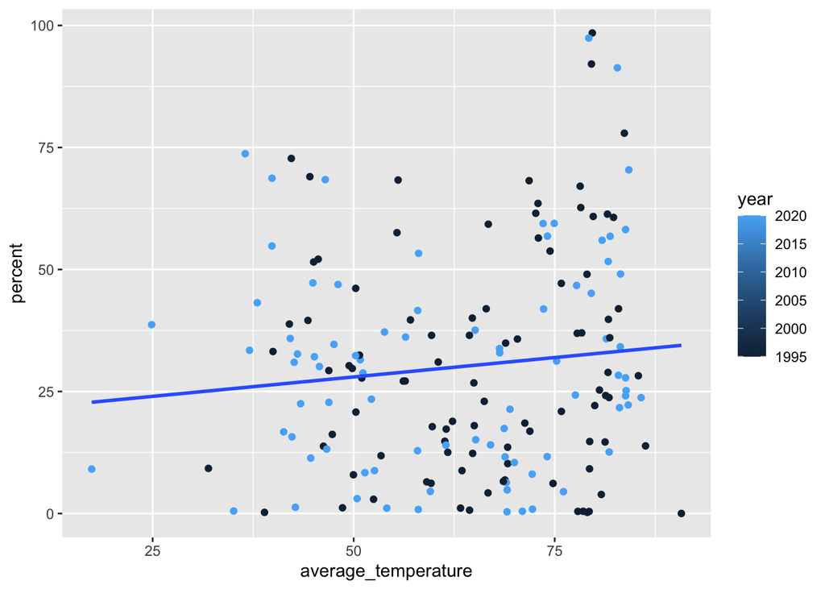

```r
final_set2 %>% filter(year==2020 | year==1995) %>% group_by(year) %>% ggplot(aes(x=average_temperature, y=percent, col=year)) + geom_point() + geom_smooth(method=lm, se=FALSE)
```

But at which temperature do the forests tend to thrive?

```r
final_set2 %>% filter(year==2020 | year==1995) %>% group_by(year) %>% filter(rank(-percent)==1) %>% summarize(country, average_temperature, percent)
```

```
## # A tibble: 2 × 4
##    year country  average_temperature percent
##   <dbl> <chr>                  <dbl>   <dbl>
## 1  1995 Suriname                79.7    98.5
## 2  2020 Suriname                79.2    97.4
```

The temperature at which the highest percentage of forestry occurs at around 79 degrees.

But does this mean that forestry always thrives at 79 degrees?

```r
final_set2 %>% group_by(temperature_range = factor(round(average_temperature/10)*10)) %>% reframe(average_percent = mean(percent, na.rm=TRUE)) %>% arrange(rank(-average_percent))
```

```
## # A tibble: 8 × 2
##   temperature_range average_percent
##   <fct>                       <dbl>
## 1 40                          38.4
## 2 80                          34.9
## 3 70                          30.4
## 4 50                          29.2
## 5 20                          23.9
## 6 60                          23.7
## 7 90                          18.3
## 8 30                           9.15
```

Actually, the highest average percentage of forestry occurred in the 35-44 degree range, with 38% forestry. The range holding the instance of highest percentage of forestry (which was 79 degrees) is the next ranked temperature range, with 35% forestry on average across the countries.

What if “thrive” was taken to mean growth?

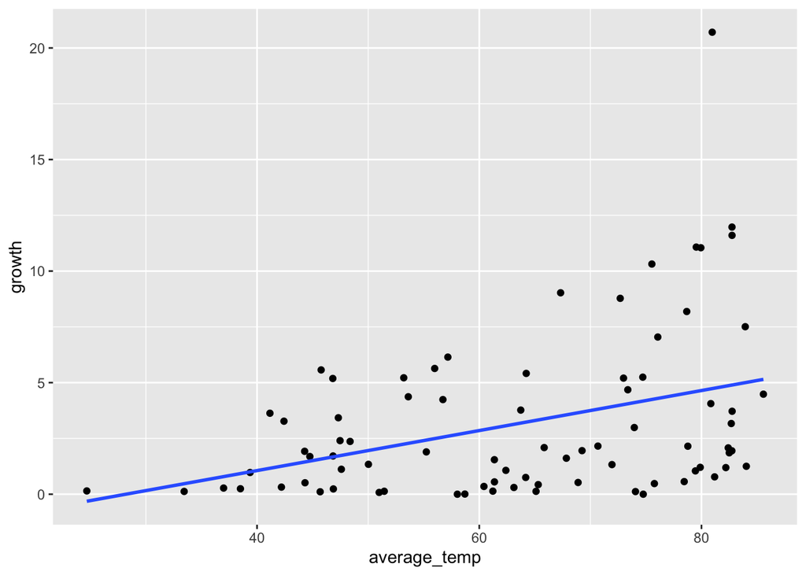

```r
final_set2 %>% filter(year==1995 | year==2020) %>% group_by(country) %>% reframe(average_temp = mean(average_temperature), growth = abs(diff(percent))) %>% ggplot(aes(x=average_temp, y=growth)) + geom_point() + geom_smooth(method=lm, se=FALSE)
```

What is the temperature with the most growth?

```r
final_set2 %>% filter(year==1995 | year==2020) %>% group_by(country) %>% reframe(average_temp = mean(average_temperature), growth = abs(diff(percent))) %>% filter(rank(-growth)==1) %>% summarize(country, average_temp, growth)
```

```
## # A tibble: 1 × 3
##   country   average_temp growth
##   <chr>            <dbl>  <dbl>
## 1 Nicaragua         81.0   20.7
```

The largest growth in percent forestry was 20% in Nicaragua, at an average temperature of 81 degrees.

Which temperature range has the most growth on average?

```r
final_set2 %>% filter(year==1995 | year==2020) %>% group_by(country) %>% reframe(average_temp = mean(average_temperature), growth = abs(diff(percent))) %>% ungroup() %>% group_by(temperature_range = factor(round(average_temp/10)*10)) %>% reframe(average_growth = mean(growth, na.rm=TRUE)) %>% arrange(rank(-average_growth))
```

```
## # A tibble: 8 × 2
##   temperature_range average_growth
##   <fct>                      <dbl>
## 1 80                         5.43
## 2 90                         4.48
## 3 70                         2.89
## 4 50                         2.38
## 5 60                         2.12
## 6 40                         1.43
## 7 20                         0.147
## 8 30                         0.124
```

The 75-84 degree temperature range shows the greatest average growth. This is consistent with the results from the previous section.

# Does geographical location affect the tendency of forests to grow or decline?

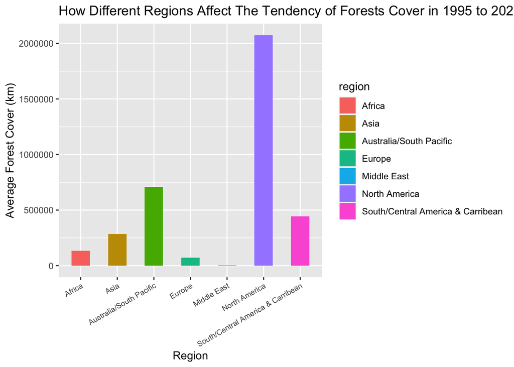

```r
final_set2 %>%
  select(region, year, km) %>%
  group_by(region) %>%
  summarize(mean_km = mean(km, na.rm = TRUE)) %>%
  ggplot(aes(region, mean_km, fill = region)) +
  labs(x = "Region", y = "Average Forest Cover (km)",
       title = "How Different Regions Affect The Tendency of Forests Cover in 1995 to 2020") +
  geom_col(width = 0.5) +
  theme(axis.text.x = element_text(angle = 30, size = 7.5, hjust = 1))
```

### Data

By selecting only columns of **region, year, km** to narrow down the data we focus on for this specific research question: “Does geographical location affect the tendency of forests to grow or decline?”. As the main goal here is find tendency from time period of 1995 to 2020 instead of focusing on each year’s tendency, we use summarize method to find the mean of km during this time period.

### Result/Analysis

By using histogram method of visualization, the graph has showed that North America have highest average forest cover, while Middle East has the lowest average forest cover.

# Over the past 25 years, what is the general trend of forest growth across the world?

```r
forest_growth <- final_set2 %>%
  group_by(year) %>%
  summarize(total_forestgrowth = sum(km, na.rm = TRUE))
print(forest_growth)
```

```
## # A tibble: 26 × 2
##     year total_forestgrowth
##    <dbl>              <dbl>
##  1  1995          23382728.
##  2  1996          23692721.
##  3  1997          23681310.
##  4  1998          23595069.
##  5  1999          23524764.
##  6  2000          23477039.
##  7  2001          23440168.
##  8  2002          23432167.
##  9  2003          23397008.
## 10  2004          23330773.
## # ℹ 16 more rows
```

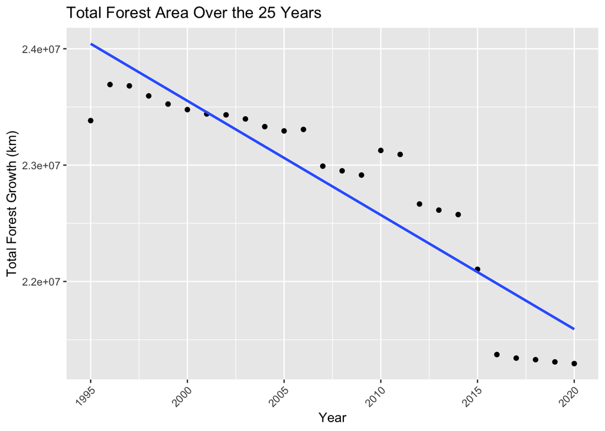

```r
ggplot(forest_growth, aes(x = year, y = total_forestgrowth)) +
  geom_point() +
   geom_smooth(method = "lm", se = FALSE) +
  labs(title = "Total Forest Area Over the 25 Years", x = "Year", y = "Total Forest Growth (km)") +
  theme(axis.text.x = element_text(angle = 45, hjust = 1))
```

### Data In this analysis of Forest Growth over the past 25 years, we totaled the Forest Area of all countries in a certain year. We then plotted the sum Forest Area vs Time graph and observed the trend.

### Results

From this graph, we observed an overall downwards trend. This entails that forest growth didn’t occur and the overal trend resulted in global forest area lost. There is this sharp drop in forest area that can’t be explained through correlation of global temperatures and forest area as we didn’t account for human intervention. As such, efforts made by humanity could have caused this sharp drop or other disasters that could have caused a sharp dorp.

# China Forest Coverage

```r
forest_growth_china <- final_set2 %>%
  group_by(year) %>%
  filter(country == "China") %>%
  summarize(total_forestgrowth = sum(km, na.rm = TRUE))

print(forest_growth_china)
```

```
## # A tibble: 26 × 2
##     year total_forestgrowth
##    <dbl>              <dbl>
##  1  1995           1670706.
##  2  1996           1690566.
##  3  1997           1710426.
##  4  1998           1730286.
##  5  1999           1750146.
##  6  2000           1770006.
##  7  2001           1793615.
##  8  2002           1817225.
##  9  2003           1840835.
## 10  2004           1864445.
## # ℹ 16 more rows
```

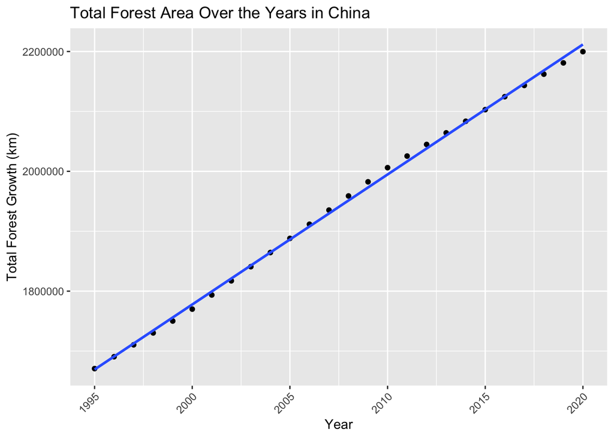

```r
ggplot(forest_growth_china, aes(x = year, y = total_forestgrowth)) +
  geom_point() +
  geom_smooth(method = "lm", se = FALSE) +
  labs(title = "Total Forest Area Over the Years in China", x = "Year", y = "Total Forest Growth (km)") +
  theme(axis.text.x = element_text(angle = 45, hjust = 1))
```

# Brazil Forest Coverage

```r
forest_growth_brazil <- final_set2 %>%
  group_by(year) %>%
  filter(country == "Brazil") %>%
  summarize(total_forestgrowth = sum(km, na.rm = TRUE))

print(forest_growth_brazil)
```

```
## # A tibble: 26 × 2
##     year total_forestgrowth
##    <dbl>              <dbl>
##  1  1995           5699933
##  2  1996           5662124.
##  3  1997           5624314.
##  4  1998           5586505.
##  5  1999           5548695.
##  6  2000           5510886
##  7  2001           5471378.
##  8  2002           5431870.
##  9  2003           5392362.
## 10  2004           5352854.
## # ℹ 16 more rows
```

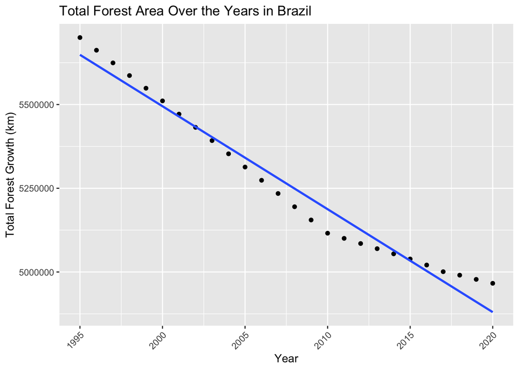

```r
ggplot(forest_growth_brazil, aes(x = year, y = total_forestgrowth)) +
  geom_point() +
  geom_smooth(method = "lm", se = FALSE) +
  labs(title = "Total Forest Area Over the Years in Brazil", x = "Year", y = "Total Forest Growth (km)") +
  theme(axis.text.x = element_text(angle = 45, hjust = 1))
```

```r
merged_data <- merge(forest_growth_brazil, forest_growth_china, by = "year", suffixes = c("_brazil", "_china"))

merged_data$difference <- merged_data$total_forestgrowth_china - merged_data$total_forestgrowth_brazil

print(merged_data)
```

```
##    year total_forestgrowth_brazil total_forestgrowth_china difference
## 1  1995                   5699933                  1670706   -4029227
## 2  1996                   5662124                  1690566   -3971558
## 3  1997                   5624314                  1710426   -3913889
## 4  1998                   5586505                  1730286   -3856219
## 5  1999                   5548695                  1750146   -3798550
## 6  2000                   5510886                  1770006   -3740880
## 7  2001                   5471378                  1793615   -3677763
## 8  2002                   5431870                  1817225   -3614645
## 9  2003                   5392362                  1840835   -3551527
## 10 2004                   5352854                  1864445   -3488410
## 11 2005                   5313346                  1888055   -3425292
## 12 2006                   5273839                  1911664   -3362174
## 13 2007                   5234331                  1935274   -3299056
## 14 2008                   5194823                  1958884   -3235939
## 15 2009                   5155315                  1982494   -3172821
## 16 2010                   5115807                  2006104   -3109703
## 17 2011                   5100415                  2025472   -3074944
## 18 2012                   5085023                  2044839   -3040184
## 19 2013                   5069632                  2064207   -3005425
## 20 2014                   5054240                  2083575   -2970665
## 21 2015                   5038848                  2102942   -2935906
## 22 2016                   5020821                  2124599   -2896222
## 23 2017                   5000916                  2143395   -2857521
## 24 2018                   4990514                  2162190   -2828324
## 25 2019                   4977985                  2180986   -2796999
## 26 2020                   4966196                  2199782   -2766414
```

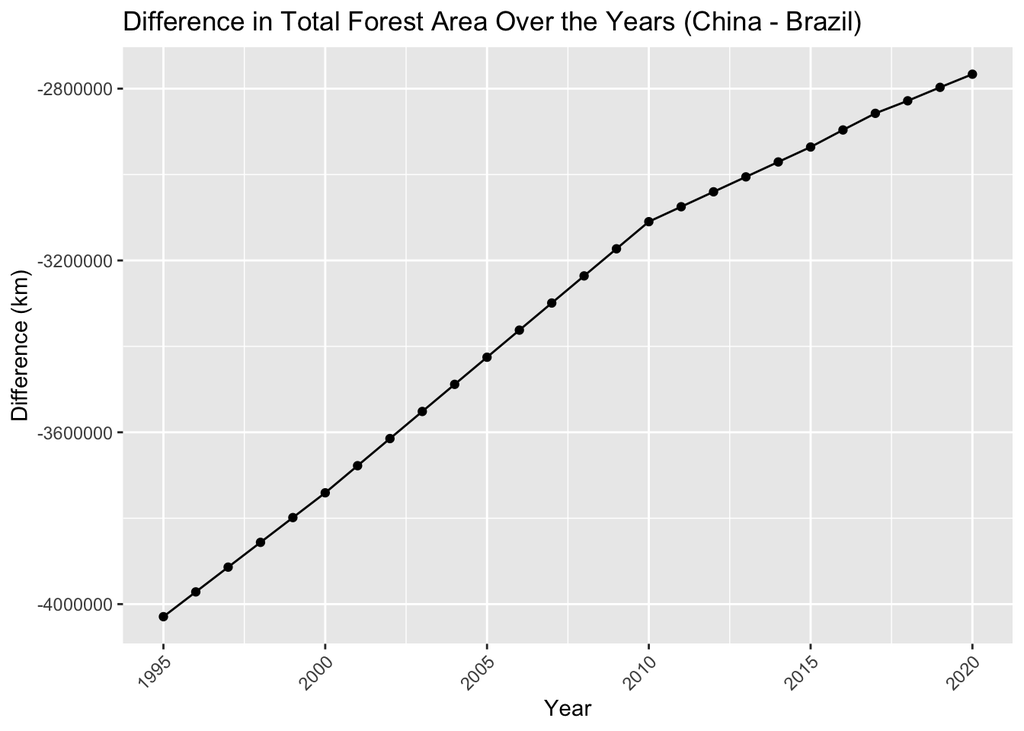

```r
ggplot(merged_data, aes(x = year, y = difference)) +
  geom_point() +
  geom_line() +
  labs(title = "Difference in Total Forest Area Over the Years (China - Brazil)", x = "Year", y = "Difference (km)") +
  theme(axis.text.x = element_text(angle = 45, hjust = 1))
```